### Question 1

Have you completed the week 3 Teradata practice exercises guide?

Yes  
No

### Question 2

**It is important that you work through the Teradata exercises for before attempting this quiz!**

Given Table A (first table to be entered in the query) and Table B (second table to be entered in the query) the query result shown below is a result of what kind of join?

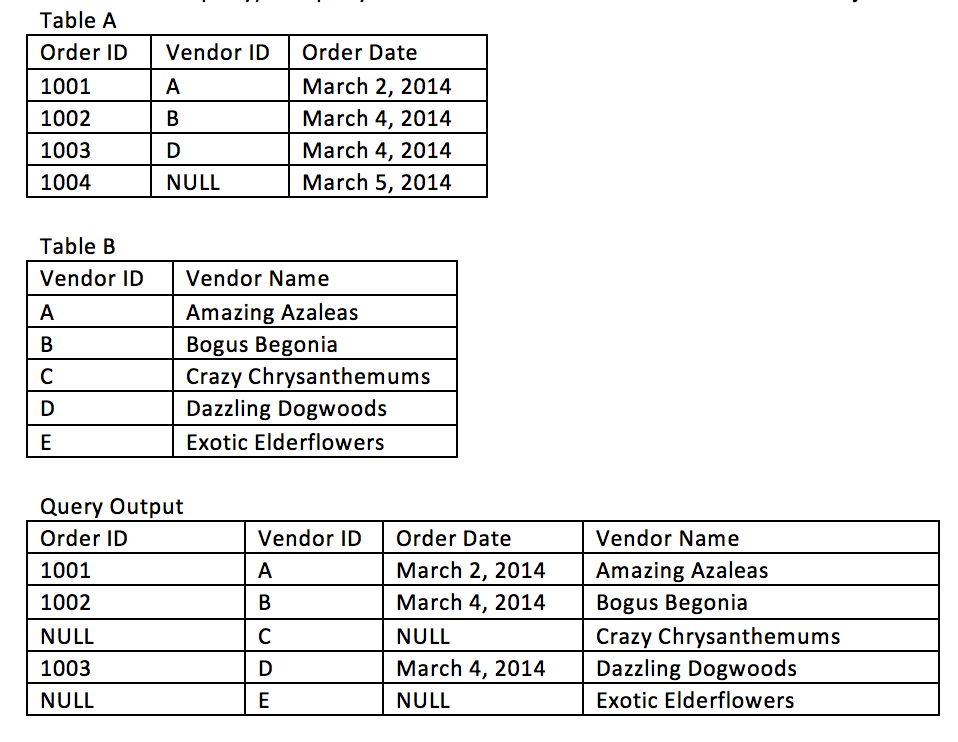

Full Outer Join  
Left Join  
Inner Join  
Right Join

### Question 3

On what day was Dillard’s income based on total sum of purchases the greatest

05/02/28  
04/12/18  
05/02/01  
04/11/01

### Question 4

What is the deptdesc of the departments that have the top 3 greatest numbers of skus from the skuinfo table associated with them?

INVEST, POLOMEN, BRIOSO  
BORA, C KLEIN, BLUE  
CLINIQUE, CELEBRT, NOB  
LACOSTE, LOUISVL, LESLIE

### Question 5

Which table contains the most distinct sku numbers?

skuinfo  
transact  
skstinfo  
deptinfo

### Question 6

How many skus are in the skstinfo table, but NOT in the skuinfo table?

803,966  
2388  
90,334  
0

### Question 7

**What is the average amount of profit Dillard’s made per day?**

$6,921,454  
$30,222,191  
$400,893,380  
$1,527,903

### Question 8

The store_msa table provides population statistics about the geographic location around a store. Using one query to retrieve your answer, how many MSAs are there within the state of North Carolina (abbreviated “NC”), and within these MSAs, what is the lowest population level (msa_pop) and highest income level (msa_income)?

16 MSAs, lowest population of 439,117, highest income level of $26,879  
12 MSAs, lowest population of 5,797, highest income level of $26,879  
12 MSAs, lowest population of 339,511, highest income level of $56,099  
16 MSAs, lowest population of 339,511, highest income level of $36,151

### Question 9

What department (with department description), brand, style, and color brought in the greatest total amount of sales?

Department 6400 described as Blue, brand Designer, style 6 7002-9, color edp spray  
Department 800 described as Clinique, brand Clinique, style 6142, color DDML  
Department 2200 described as Celebrt, brand Lancome, style 1924, color resol eye  
Department 4407 described as Environ, brand Silver C, style TO02SCBELT-S , color silver

### Question 10

How many stores have more than 180,000 distinct skus associated with them in the skstinfo table?

4  
12  
20  
31

### Question 11

Look at the data from all the distinct skus in the “cop” department with a “federal” brand and a “rinse wash” color. You'll see that these skus have the same values in some of the columns, meaning that they have some features in common.

**In which columns do these skus have different values from one another, meaning that their features differ in the categories represented by the columns?** Choose all that apply. Note that you will need more than a single correct selection to answer the question correctly.

style  
size  
vendor  
pack size

### Question 12

How many skus are in the skuinfo table, but NOT in the skstinfo table?

803,966  
0  
2388  
90,334

### Question 13

In what city and state is the store that had the greatest total sum of sales?

McAllen, TX  
Metairie, LA  
Dallas, TX  
Little Rock, AK

### Question 14

Given Table A (first table to be entered in the query) and Table B (second table to be entered in the query) the query result shown below is a result of what kind of join?

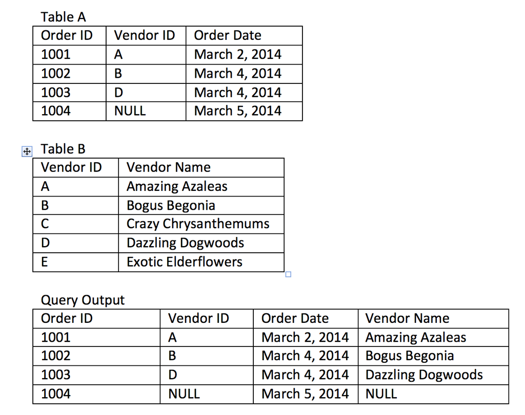

Full Outer Join  
Right Join  
Inner Join  
Left Join

### Question 15

How many states have more than 10 Dillards stores in them?

15  
24  
5  
9

### Question 16

What is the suggested retail price of all the skus in the “reebok” department with the “skechers” brand and a “wht/saphire” color?

$19.00  
$29.00  
$4.00  
$39.00